# Measles state-space model fitted using `pomp`

Andrew Tredennick

16 August, 2018

## The data

First, we load the data and aggregate the weekly case reports into biweekly reports to match the time step of our process model.

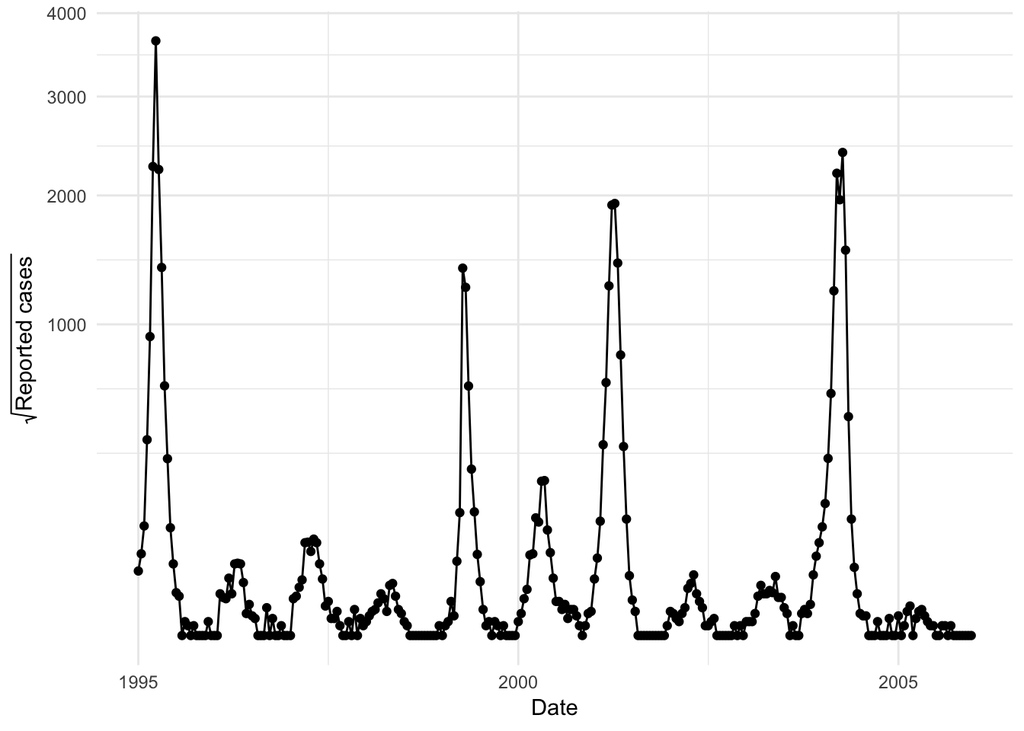

```r
file_name <- "../../niger_measles/niger_regional_1995_2005.csv"
niger_measles_raw <- read_csv(file_name, col_types = cols())

num_regions <- nrow(niger_measles_raw)
num_weeks <- ncol(niger_measles_raw) - 1  # subtract 1 from ncol() because first column are regions
weeks_per_year <- num_weeks/11
weeks <- rep(1:52, times = 11)

# Create a vector of years for all num_weeks
years <- rep(1995:2005, each = weeks_per_year)

# Function for calculating start of week based on week number and year
calculate_start_of_week = function(week, year) {
  date <- ymd(paste(year, 1, 1, sep="-"))
  week(date) = week
  return(date)
}

# Clean up the data frame
measles_data <- niger_measles_raw %>%
  gather(key = week, value = cases, -X1) %>%
  mutate(
    week_num = rep(1:num_weeks, each = num_regions),
    year = rep(years, each  = num_regions),
    week = rep(weeks, each = num_regions),
    date = calculate_start_of_week(week, year)
  ) %>%
  dplyr::rename(region = X1) %>%
  filter(region == "Niamey (City)")

# Read in population data and estimate births
population <- read_csv("../../niger_measles/district_pops.csv") %>%
  gather(key = year, value = population, -X1) %>%
  rename(district = X1) %>%
  filter(district == "Niamey I")

birth_rates <- read_csv("../../niger_measles/niger_crude_birth_rates.csv") %>%
  mutate(
    date = mdy(date),  # lubridate prefixes any 2digit year 00-68 with 20, not a problem for us though
    year = as.character(year(date)),
    rate_per_person = births_per_thousand/1000
  ) %>%
  select(year, rate_per_person)

births <- population %>%
  left_join(birth_rates, by = "year") %>%
  mutate(
    births_per_year = population * rate_per_person,
    births_per_week = births_per_year / 52
  )

# Aggregate weekly data to biweeks
biweek_data <- measles_data %>%
  mutate(biweek = rep(1:(n()/2), each = 2)) %>%
  group_by(biweek) %>%
  summarise(
    cases = sum(cases),
    date = min(date)
  ) %>%
  mutate(
    births = round(rep(births$births_per_week*2, each = 26)),
    population = round(rep(population$population, each = 26))
  )

ggplot(biweek_data, aes(x = date, y = cases)) +
  geom_point() +
  geom_line() +
  scale_y_sqrt() +
  labs(x = "Date", y = expression(paste(sqrt(Reported~cases))))
```

## The `pomp` object

Now we define the multiple parts of the `pomp` object for particle filtering.

### The process model

```r
measles_process <- Csnippet(
  "
  double dN[2];

  double beta_r = beta_mu * (1 + dot_product(K, &xi1, &b1));
  double var_epsilon = sigma_env;
  beta_r *= (var_epsilon < 1.0e-6) ? 1 : rgamma(1/var_epsilon,var_epsilon);
  double inv_lambda = exp(-beta_r * (I + psi));

  if(inv_lambda > 1){
    inv_lambda = 1;
  }
  double delta = rbinom(nearbyint(S), inv_lambda);
  dN[0] = delta + births;
  dN[1] = S - delta;
  S = nearbyint(dN[0]);
  I = nearbyint(dN[1]);
  beta_t = beta_r;
  "
)
```

### The measurement model

```r
rmeas <- Csnippet(
  "
  cases = rnbinom_mu(1/tau, rho*I);
  if (cases > 0.0) {
    cases = nearbyint(cases);
  } else {
    cases = 0.0;
  }
  "
)
```

### The likelihood density model

```r
dmeas <- Csnippet(
  "
  double mean_cases = nearbyint(rho*I);
  lik = dnbinom_mu(cases, 1/tau, mean_cases, give_log);
  "
)
```

### Mapping of transformations

This is information for `pomp` in terms of parameter transformations (e.g., to enforce strictly positive parameter values) and initial conditions estimates.

```r
# Map initial value parameters to initial values of states
init <- Csnippet(
  "
  I = nearbyint(I_0);
  S = nearbyint(S_0);
  beta_t = 0;
  "
)

# Set up parameter transformations
to_est <- Csnippet(
  "
  Tbeta_mu = log(beta_mu);
  Trho = logit(rho);
  Ttau = log(tau);
  Tsigma_env = log(sigma_env);
  TS_0 = log(S_0);
  TI_0 = log(I_0);
  Tpsi = log(psi);
  "
)

from_est <- Csnippet(
  "
  Tbeta_mu = exp(beta_mu);
  Trho = expit(rho);
  Ttau = exp(tau);
  Tsigma_env = exp(sigma_env);
  TS_0 = exp(S_0);
  TI_0 = exp(I_0);
  Tpsi = exp(psi);
  "
)
```

### Setup data and covariate tables

`pomp` requires separate `data` and `covar` tables, each with the same time column. We set those up here.

```r
# Fetch observations
obs_data <- biweek_data %>%
  dplyr::select(biweek, cases) %>%
  mutate(cases = round(cases, 0))

# Generate basis functions for seasonality
bspline_basis <- periodic.bspline.basis(
  obs_data$biweek,
  nbasis = 6,
  degree = 3,
  period = 26,
  names = "xi%d"
) %>%
  as_tibble()

# Combine with births data for covariate table
covar_data <- biweek_data %>%
  dplyr::select(biweek, births) %>%
  arrange(biweek) %>%
  bind_cols(bspline_basis)
```

### Combine everything into a `pomp` object

Now we take all the objects we created above and put them together in a `pomp` container. We also set reasonable parameter values as place holders for making sure the model can simulate data that at least qualitatively mimics the behavior of the data.

```r
# Set some realistic parameter values for testing via simulation
params <- c(
  beta_mu = 0.00001,
  b1 = 3,
  b2 = 0,
  b3 = 1.5,
  b4 = 6,
  b5 = 5,
  b6 = 3,
  psi = 1,
  rho = 0.1,
  tau = 1,
  sigma_env = 0.01,
  S_0 = 100000,
  I_0 = 100
)

# Generate pomp object
measles_pomp <- pomp(
  data = obs_data,
  time = "biweek",
  covar = covar_data,
  tcovar = "biweek",
  t0 = 1,
  rprocess = discrete.time.sim(measles_process, delta.t = 1),
  rmeasure = rmeas,
  dmeasure = dmeas,
  initializer = init,
  statenames = c("S", "I", "beta_t"),
  toEstimationScale = to_est,
  fromEstimationScale = from_est,
  paramnames = names(params),
  params = params,
  globals = "int K = 6;"
)
```

### Simulations from the model

We can use the `measles_pomp` object to simulate from the model given the parameters we fed into it. This is a good check to make sure the model is OK. We plot 9 simulations (red) along with the data (blue) below.

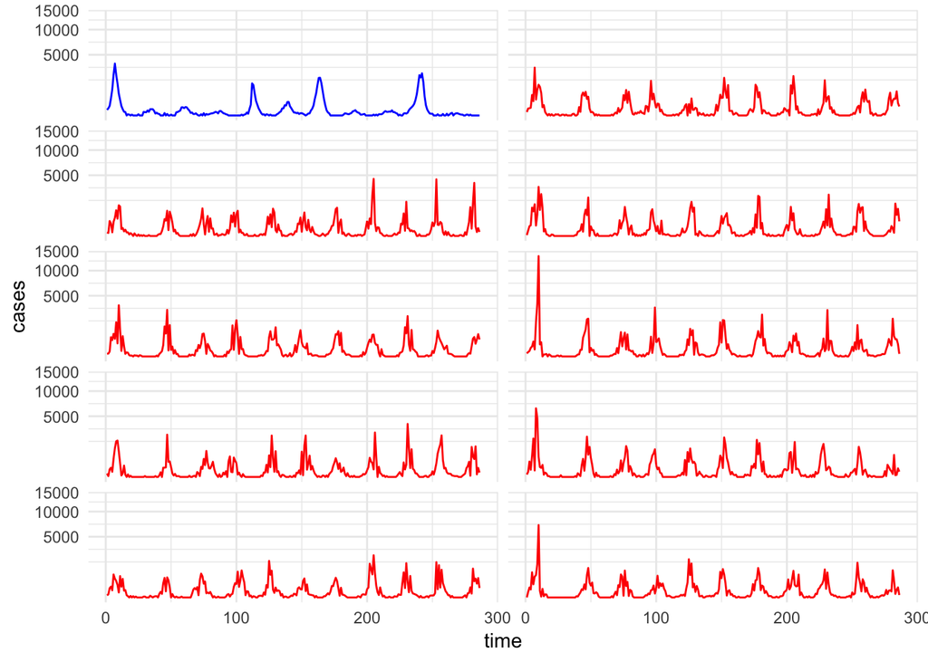

```r
simulate(
  measles_pomp,
  nsim = 9,
  as.data.frame = TRUE,
  include.data = TRUE) %>%
  ggplot(aes(x = time, y = cases, group = sim, color = (sim == "data"))) +
    geom_line() +
    scale_color_manual(values = c(`TRUE` = "blue", `FALSE` = "red"))+
    guides(color = FALSE) +
    facet_wrap(~sim, ncol = 2) +
    scale_y_sqrt() +
    theme(strip.text=element_blank())
```

It is also important to make sure the underlying likelihood model is specified properly. We can test this by running one instance of the particle filter (`pomp::pfilter()`) at the current parameter values: `logLik(pfilter(measles_pomp, Np = 1000))` = -2895. Note that at this stage we also receive the warning `in 'pfilter': 56 filtering failures occurred.` This is OK at the moment because we are not using these parameters for inference.

## Maximization by Iterated particle Filtering

We now move to actually fitting the measles SIR model, using Maximization by Iterated particle Filter (MIF). MIF varies parameters throughout the filtering process and selectively propogates parameter sets (``particles'') that have the highest likelihood given the data and model. We use the`pomp::mif2()` function to perform a grid search over parameter space that lets us hone in on the maximum likelihood estimates (MLE) for each parameter. We start with a global search, and the proceed to a localized search around the MLEs from the global search.

### Probe matching a la Wood 2010 (*Nature*)

We use the parameter estimates from this step as starting points for the MIF.

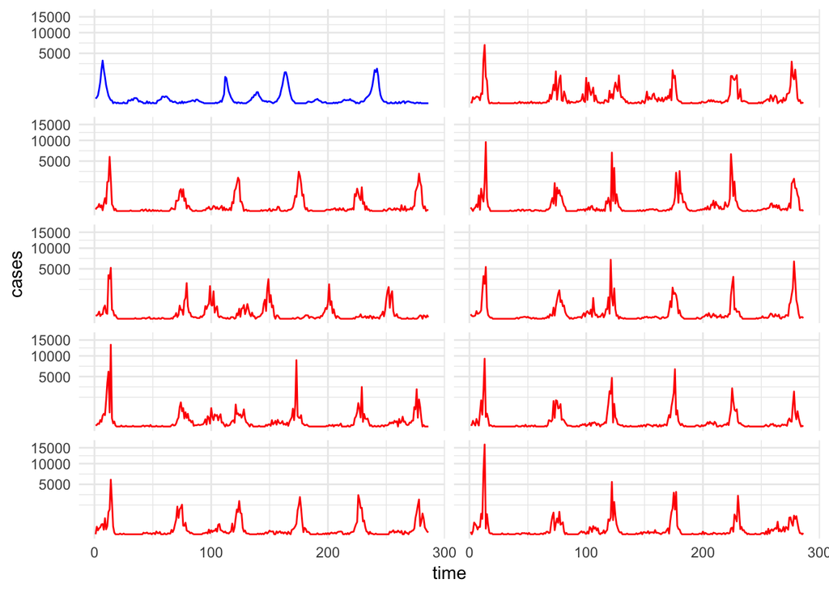

```r
probe.zeroes <- function(y){
  xy <- y["cases",]
  as.numeric(length(which(xy == 0)))
}
probe.max <- function(y){
  max(y["cases",], na.rm = TRUE)
}
probe.cumsum <- function(y){
  cases <- y["cases",1:26]
  max(cumsum(cases))
}

# probe(measles_pomp, probes = list(probe.zeroes), nsim = 500)

plist <- list(
  probe.zeroes,
  probe.max,
  probe.cumsum,
  probe.acf("cases", lags = 1,transform = sqrt, type = "correlation")
)


stew(
  file = "probe_match_results.rda", {
    pm <- probe.match(
      measles_pomp,
      probes = plist,
      est = names(params),
      nsim = 500,
      transform = TRUE,
      start = params,
      method = "Nelder-Mead",
      maxit = 10000
    )
  },
  seed = 290860832,
  kind = "L'Ecuyer"
)

pm_ll <- logLik(pfilter(measles_pomp, Np = 1000, params = coef(pm)))

simulate(
  measles_pomp,
  params = coef(pm),
  nsim = 9,
  as.data.frame = TRUE,
  include.data = TRUE) %>%
  ggplot(aes(x = time, y = cases, group = sim, color = (sim == "data"))) +
    geom_line() +
    scale_color_manual(values = c(`TRUE` = "blue", `FALSE` = "red"))+
    guides(color = FALSE) +
    facet_wrap(~sim, ncol = 2) +
    scale_y_sqrt() +
    theme(strip.text=element_blank())
```

The log-likelihood at these parameter values is -2787.8510691.

### MIF search

```r
probe_ests <- coef(pm)

make_guess <- function(params, sd_perc = 0.1){
  n <- length(params)
  out <- numeric(n)
  for(i in 1:n){
    out[i] <- rnorm(1, params[i], abs(params[i])*sd_perc)
  }
  names(out) <- names(params)
  return(out)
}

stew(file="mif1.rda",{
  w1 <- getDoParWorkers()
  t1 <- system.time({
    m1 <- foreach(i=1:20,.packages='pomp',.combine=rbind,
                  .options.multicore=list(set.seed=TRUE)
    ) %dopar% {
      guess <- make_guess(probe_ests, sd_perc = 0.2)
      mf <- mif2(measles_pomp,
                 start=c(guess),
                 Np=1000,
                 Nmif=50,
                 cooling.type="geometric",
                 cooling.fraction.50=1,
                 transform=TRUE,
                 rw.sd=rw.sd(
                   beta_mu=0.02, rho=0.02, tau=0.01, sigma_env = 0.02,
                   b1 = 0.02, b2 = 0.02, b3 = 0.02, b4 = 0.02, b5 = 0.02, b6 = 0.02,
                   I_0=ivp(0.1), S_0=ivp(0.1), psi = 0.02
                 )
                )
      ll <- logmeanexp(replicate(10,logLik(pfilter(mf,Np=5000))),se=TRUE)
      data.frame(as.list(coef(mf)),loglik=ll[1],loglik.se=ll[2])
    }
  })
},seed=290860873,kind="L'Ecuyer")

m1_ests <- m1 %>%
  as_tibble() %>%
  arrange(-loglik) %>%
  mutate(
    rownum = 1:n()
  ) %>%
  filter(rownum <= 10) %>%
  select(-loglik, -loglik.se, -rownum)



stew(file="mif2.rda",{
  w2 <- getDoParWorkers()
  t2 <- system.time({
    m2 <- foreach(i=1:10,.packages='pomp',.combine=rbind,
                  .options.multicore=list(set.seed=TRUE)
    ) %dopar% {
      guess <- make_guess(unlist(m1_ests[i,]), sd_perc = 0.2)
      mf <- mif2(measles_pomp,
                 start=c(guess),
                 Np=1000,
                 Nmif=50,
                 cooling.type="geometric",
                 cooling.fraction.50=0.5,
                 transform=TRUE,
                 rw.sd=rw.sd(
                   beta_mu=0.02, rho=0.02, tau=0.01, sigma_env = 0.02,
                   b1 = 0.02, b2 = 0.02, b3 = 0.02, b4 = 0.02, b5 = 0.02, b6 = 0.02,
                   I_0=ivp(0.1), S_0=ivp(0.1), psi = 0.02
                 )
                )
      ll <- logmeanexp(replicate(10,logLik(pfilter(mf,Np=5000))),se=TRUE)
      data.frame(as.list(coef(mf)),loglik=ll[1],loglik.se=ll[2])
    }
  })
},seed=2908873,kind="L'Ecuyer")



iter2_coef <- m2 %>%
  as_tibble() %>%
  filter(loglik == max(loglik)) %>%
  select(-loglik, -loglik.se) %>%
  unlist()

(ll_end <- logmeanexp(replicate(50, logLik(pfilter(measles_pomp, params = iter2_coef, Np=5000))),se=TRUE))
```

```
##                        se
## -888.6318386    0.2537844
```

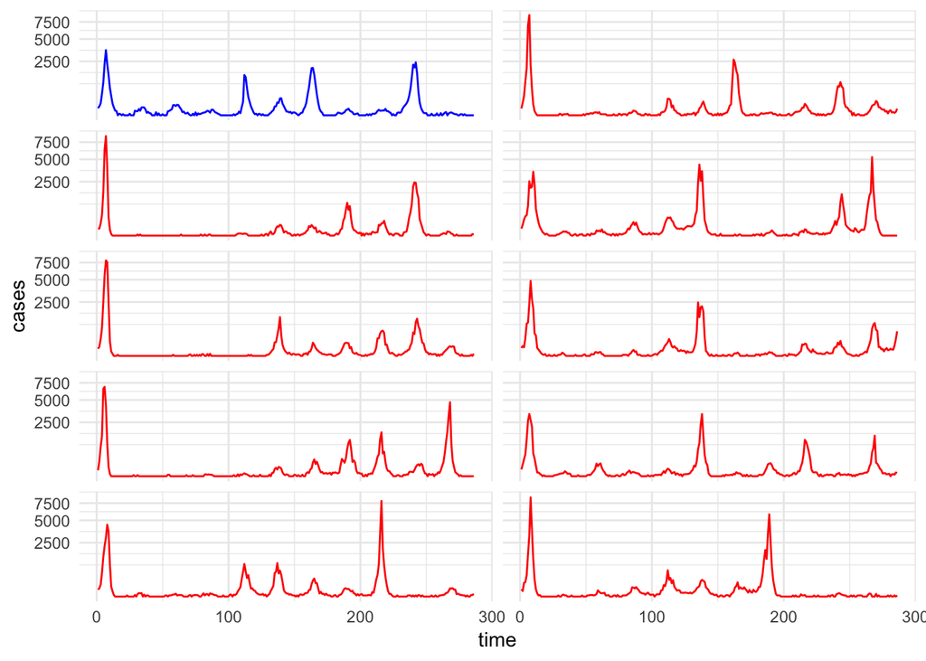

```r
simulate(
  measles_pomp,
  params = iter2_coef,
  nsim = 9,
  as.data.frame = TRUE,
  include.data = TRUE) %>%
  ggplot(aes(x = time, y = cases, group = sim, color = (sim == "data"))) +
    geom_line() +
    scale_color_manual(values = c(`TRUE` = "blue", `FALSE` = "red"))+
    guides(color = FALSE) +
    facet_wrap(~sim, ncol = 2) +
    scale_y_sqrt() +
    theme(strip.text=element_blank())
```

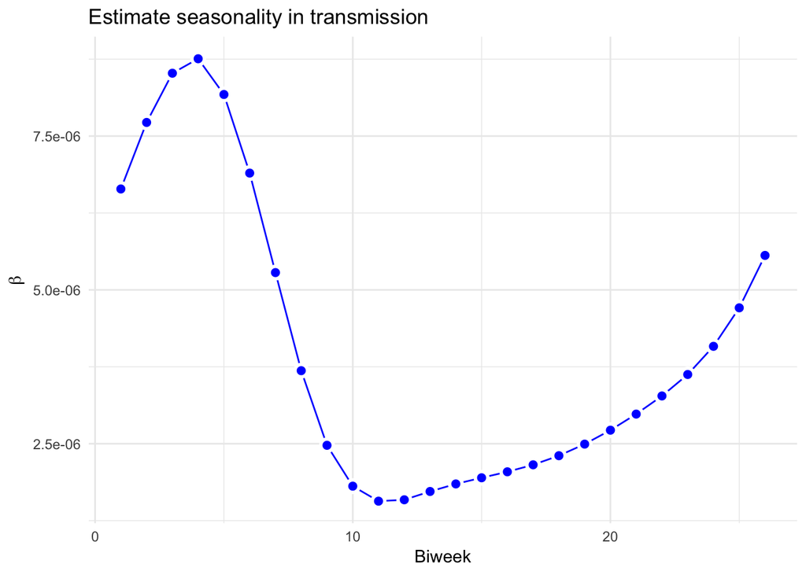

```r
bs <- iter2_coef[c("b1","b2","b3","b4","b5","b6")]
beta_season <- (as.matrix(bspline_basis[1:26,]) %*% bs) * iter2_coef["beta_mu"]
betas <- tibble(
  beta_value = as.numeric(beta_season),
  biweek = 1:26
)

ggplot(betas, aes(x = biweek, y = beta_value)) +
  geom_line(color = "blue") +
  geom_point(color = "white", size = 4) +
  geom_point(color = "blue", size = 2) +
  ylab(expression(beta)) +
  xlab("Biweek") +
  ggtitle("Estimate seasonality in transmission")
```

Now time to estimate the states with empirical Bayes.

### Empirical Bayes for state-space reconstruction

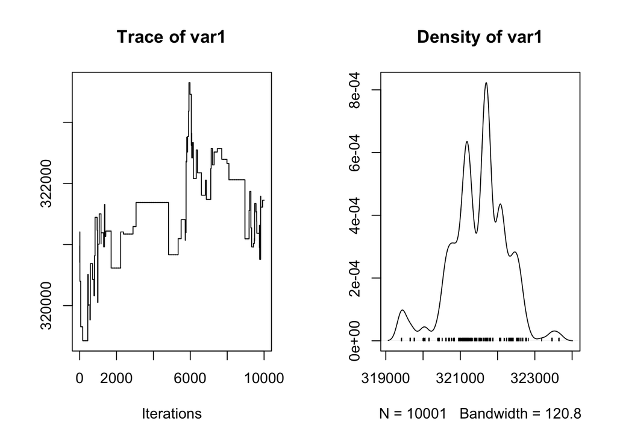

```r
hyperparams <- list(min = iter2_coef/10, max = iter2_coef * 10)

measles_dprior <- function (params, ..., log) {
 f <- sum(dunif(params, min = hyperparams$min, max = hyperparams$max, log = TRUE))
 if (log) f else exp(f)
}



stew(
  file = "pmcmc_results.rda",
  {
    chain <- pmcmc(
      pomp(measles_pomp, dprior = measles_dprior),
      Nmcmc=2000,
      Np=100,
      start= iter2_coef,
      max.fail=Inf,
      proposal = mvn.diag.rw(
        rw.sd = c(
          beta_mu=0.00001,
          b1 = 1,
          b2 = 1,
          b3 = 1,
          b4 = 1,
          b5 = 1,
          b6 = 1,
          S_0 = 1000,
          psi = 0.1,
          sigma_env = 0.1,
          tau = 0.001,
          I_0 =10,
          rho =0.01
        )
      )
    )

  mcmcout <- chain %>% pmcmc(Nmcmc=10000,proposal=mvn.rw(covmat(chain)))
  },
  seed=29012387, kind="L'Ecuyer"
)

traces <- conv.rec(mcmcout)
traces <- window(traces,thin=1,start=1)
plot(traces[,"S_0"])
```

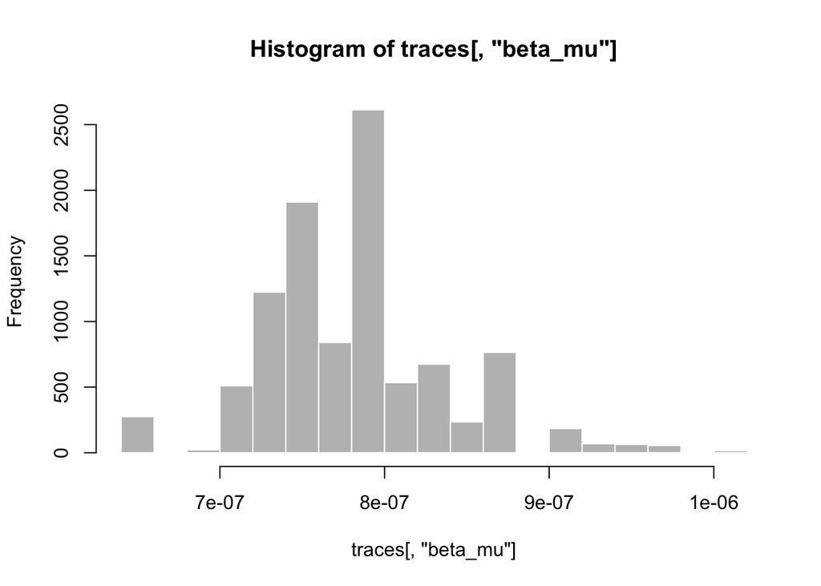

```r
hist(traces[,"beta_mu"], col = "grey", border = "white")
```

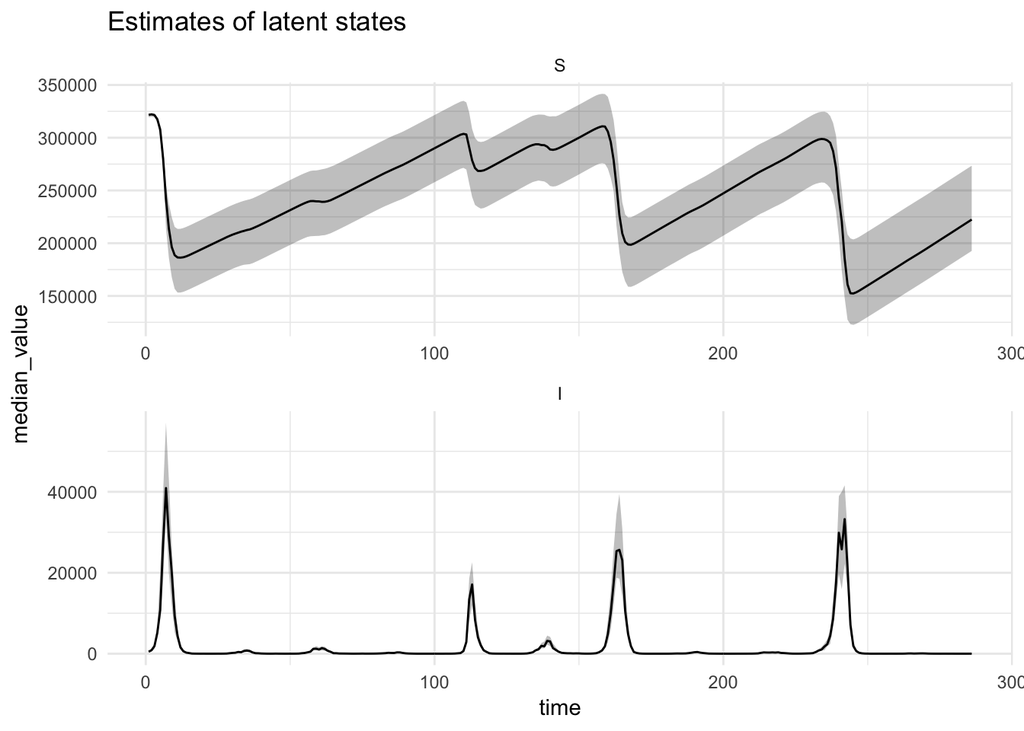

```r
mle_rho = mean(traces[,"rho"])

test <- mcmcout %>%
  filter.traj() %>%
  reshape2::melt() %>%
  as_tibble() %>%
  filter(variable != "beta_t") %>%
  # filter(rep > 1000) %>%
  dplyr::group_by(variable, time) %>%
  dplyr::summarise(
    median_value = quantile(value, 0.5),
    upper_value = quantile(value, 0.975),
    lower_value = quantile(value, 0.025)
  )

ggplot(test, aes(x = time)) +
  geom_ribbon(aes(ymin = lower_value, ymax = upper_value), alpha = 0.3) +
  geom_line(aes(y = median_value)) +
  facet_wrap(~variable, scales = "free", ncol = 1) +
  ggtitle("Estimates of latent states")
```

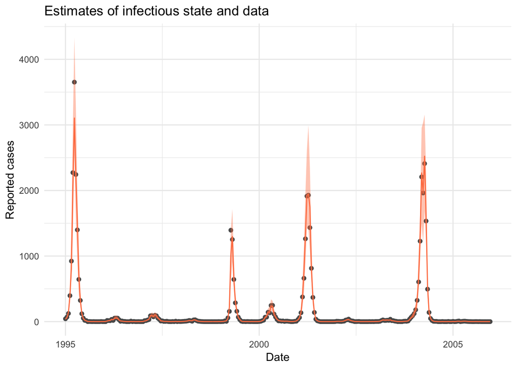

```r
pred_obs <- test %>%
  filter(variable == "I") %>%
  mutate(
    median_value = median_value*mle_rho,
    upper_value = upper_value*mle_rho,
    lower_value = lower_value*mle_rho,
    cases = biweek_data$cases,
    date = biweek_data$date
  )

ggplot(pred_obs, aes(x = date)) +
  geom_point(aes(y = cases), color = "grey35") +
  geom_ribbon(aes(ymin = lower_value, ymax = upper_value), fill = "coral", alpha = 0.4) +
  geom_line(aes(y = median_value), color = "coral") +
  labs(x = "Date", y = "Reported cases") +
  ggtitle("Estimates of infectious state and data")
```

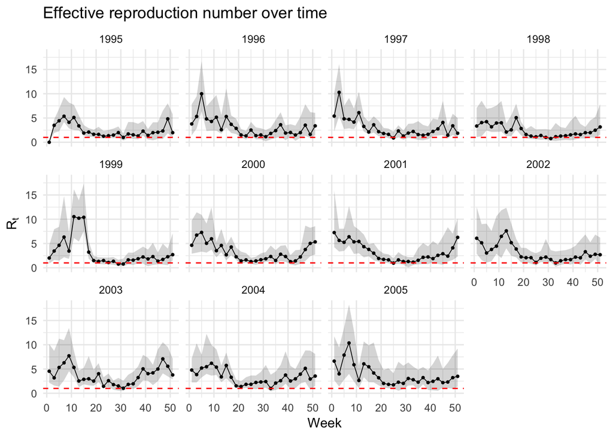

```r
popsmooth <- predict(lm(biweek_data$population~biweek_data$biweek), x=biweek_data$biweek)

reff_time <- mcmcout %>%
  filter.traj() %>%
  reshape2::melt() %>%
  as_tibble() %>%
  filter(variable == "beta_t") %>%
  mutate(
    date = rep(biweek_data$date, each = length(unique(rep))),
    population = rep(popsmooth, each = length(unique(rep)))
  ) %>%
  dplyr::group_by(variable, date) %>%
  dplyr::summarise(
    median_value = median(value*population),
    upper_value = quantile(value*population, 0.975),
    lower_value = quantile(value*population, 0.025)
  )

ggplot(reff_time, aes(x = week(date), y = median_value)) +
  geom_ribbon(aes(ymin = lower_value, ymax = upper_value), alpha = 0.2) +
  geom_line(size = 0.3) +
  geom_point(size = 0.7) +
  geom_hline(aes(yintercept = 1), color = "red", linetype = 2) +
  facet_wrap(~year(date)) +
  xlab("Week") +
  ylab(expression(R[t])) +
  ggtitle("Effective reproduction number over time")
```